# Fun size reproducibility presents…

## A table showing characteristics of transgender survey participants

This is a brief reproduction of data analysis featured in an [article from Breast Cancer Research and Treatment](https://www.ncbi.nlm.nih.gov/pubmed/28828563) published on August 21, 2017. The authors used data from the [2014 Behavioral Risk Factor Surveillance Survey](https://www.cdc.gov/brfss/annual_data/annual_2014.html) to examine breast cancer screening in transgender patients.

We reproduced Table 1 using [R 3.4.1](https://www.r-project.org/) and the following packages: [*haven*](https://cran.r-project.org/web/packages/haven/index.html) (for reading in the online zipped XPT file), [*knitr*](https://cran.r-project.org/web/packages/knitr/index.html), and [*kableExtra*](https://cran.r-project.org/web/packages/kableExtra/index.html) (for formatting the table).

Here is the original table:

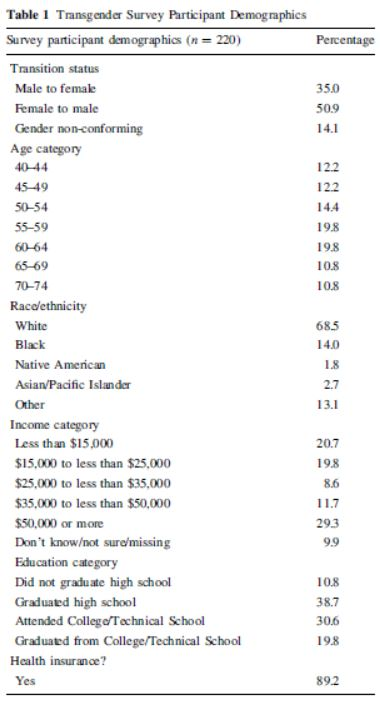

### Libraries & data management

The data used in the paper were from a publicly available source on the [2014 Behavioral Risk Factor Surveillance Survey website](https://www.cdc.gov/brfss/annual_data/annual_2014.html). Two file types are available: ASCII and XPT. We used the XPT file. The file was zipped, requiring an additional step for download.

Here we load the haven library, read in the data, unzip it, and wrangle it into a useful data set for building the table.

```r
#bring in data file
library(haven) #for read_xpt (auto unzips as well)
temp <- tempfile(fileext = ".zip") # create tempfile
download.file("http://www.cdc.gov/brfss/annual_data/2014/files/LLCP2014XPT.zip",temp) #get data
brfss2014 <-read_xpt(temp) #unzip & read in
brfss2014 #inspect
unlink(temp)

#subset the transgender participants, 40-74 years old, with mammogram data
trans2014 <- subset(brfss2014, TRNSGNDR < 4 & `_AGEG5YR` > 4 & `_AGEG5YR` < 12 & HADMAM != 7 )

#make a smaller data set with just variables in table 1
table1vars <- c("TRNSGNDR", "_AGEG5YR", "_RACE","_INCOMG",
                "_EDUCAG","HLTHPLN1","HADMAM")
trans2014small <- trans2014[table1vars]

#make the variables factors
#adds an X in front of variable names starting with underscore
trans2014small <- data.frame(lapply(trans2014small, factor))

#add category labels to each factor
levels(trans2014small$TRNSGNDR) = c('Male to female','Female to male','Gender non-conforming')
levels(trans2014small$X_AGEG5YR) = c('40-44','45-49','50-54',
                                     '55-59','60-64','65-69',
                                     '70-74')
#inconsistent with the paper labels
#Pacific Islanders were coded as other and not with
#Asian
levels(trans2014small$X_RACE) = c('White','Black','Native American',
                                  'Asian/Pacific Islander',
                                  'Other', 'Other','Other','Other')
levels(trans2014small$X_INCOMG) = c('Less than $15,000',
                                    '$15,000 to less than $25,000',
                                    '$25,000 to less than $35,000',
                                    '$35,000 to less than $50,000',
                                    '$50,000 or more','Don\'t know/not sure/missing')
levels(trans2014small$X_EDUCAG) = c('Did not graduate high school',
                                    'Graduated high school',
                                    'Attended College/Technical School',
                                    'Graduated from College/Technical School')
levels(trans2014small$HLTHPLN1) = c('Yes','No')
```

### Data analysis

Here we used a function to find percentages for all the variables in the small data set, created a new data frame with the percentages, and removed groups from the data set that were not displayed in the original table.

```r
#make a table of the percentages
#transgender variable is n=220 but others are
#inconsistent with the paper use n=222 for
#reproducing percentages correctly
#remove 2 cases from transgender variable
trans2014small$TRNSGNDR[trans2014small$HADMAM == 9] <- NA

#finding percentages and rounding to one decimal place
tblFun <- function(x){
    percs <- cbind(round(prop.table(table(x))*100,1))
}

#make a data frame of results
fullTable <- do.call(rbind,lapply(trans2014small,tblFun))

#remove Healthcare No category and HADMAM categories
#label the percentage column
fullTable <- data.frame(fullTable[c(1:26),])
colnames(fullTable) <- "Percentage"
#create a variable from the rownames and label the variable
fullTable <- cbind("Survey participant demographics"=rownames(fullTable), fullTable)
```

### Making the table

Note that the options for formatting tables are limited in R (although they are getting better all the time!) so reproducing the table *exactly* as it is shown in the published paper would require developing some more sophistocated code. Using existing formatting options in knitr and kableExtra we were able to get very close to the published format and a pretty good-looking table:

```r
#format the table
library(knitr)
library(kableExtra)
fullTable %>%
kable("html", caption = "Transgender Survey Participant Demographics (n=222)",
      style = "ajs", row.names = FALSE) %>%
  group_rows("Transition status (n=220)", 1, 3) %>%
  group_rows("Age category", 4, 10) %>%
  group_rows("Race/ethnicity", 11, 15) %>%
  group_rows("Income category", 16, 21) %>%
  group_rows("Education category", 22, 25) %>%
  group_rows("Health insurance?", 26, 26)
```

Transgender Survey Participant Demographics (n=222)

| Survey participant demographics | Percentage |
| --- | --- |
| **Transition status (n=220)** |  |
| Male to female | 35.0 |
| Female to male | 50.9 |
| Gender non-conforming | 14.1 |
| **Age category** |  |
| 40-44 | 12.2 |
| 45-49 | 12.2 |
| 50-54 | 14.4 |
| 55-59 | 19.8 |
| 60-64 | 19.8 |
| 65-69 | 10.8 |
| 70-74 | 10.8 |
| **Race/ethnicity** |  |
| White | 68.5 |
| Black | 14.0 |
| Native American | 1.8 |
| Asian/Pacific Islander | 2.7 |
| Other | 13.1 |
| **Income category** |  |
| Less than $15,000 | 20.7 |
| $15,000 to less than $25,000 | 19.8 |
| $25,000 to less than $35,000 | 8.6 |
| $35,000 to less than $50,000 | 11.7 |
| $50,000 or more | 29.3 |
| Don’t know/not sure/missing | 9.9 |
| **Education category** |  |
| Did not graduate high school | 10.8 |
| Graduated high school | 38.7 |
| Attended College/Technical School | 30.6 |
| Graduated from College/Technical School | 19.8 |
| **Health insurance?** |  |
| Yes | 89.2 |